## Python

```python
x = 2
x += 1
print x
```

```
3
```

# Pandas

Reading a data frame.

Import Credit Scoring data (https://onlinecourses.science.psu.edu/stat857/node/215)

When a bank receives a loan application, based on the applicant’s profile the bank has to make a decision regarding whether to go ahead with the loan approval or not. Two types of risks are associated with the bank’s decision –

- If the applicant is a good credit risk, i.e. is likely to repay the loan, then not approving the loan to the person results in a loss of business to the bank
- If the applicant is a bad credit risk, i.e. is not likely to repay the loan, then approving the loan to the person results in a financial loss to the bank The German Credit Data contains data on 20 variables and the classification whether an applicant is considered a Good or a Bad credit risk for 1000 loan applicants

```python
import pandas as pd

df = pd.read_csv('https://onlinecourses.science.psu.edu/stat857/sites/onlinecourses.science.psu.edu.stat857/files/german_credit.csv')

df
```

|  | Creditability | Account Balance | Duration of Credit (month) | Payment Status of Previous Credit | Purpose | Credit Amount | Value Savings/Stocks | Length of current employment | Instalment per cent | Sex & Marital Status | ... | Duration in Current address | Most valuable available asset | Age (years) | Concurrent Credits | Type of apartment | No of Credits at this Bank | Occupation | No of dependents | Telephone | Foreign Worker |
| --- | --- | --- | --- | --- | --- | --- | --- | --- | --- | --- | --- | --- | --- | --- | --- | --- | --- | --- | --- | --- | --- |
| 0 | 1 | 1 | 18 | 4 | 2 | 1049 | 1 | 2 | 4 | 2 | ... | 4 | 2 | 21 | 3 | 1 | 1 | 3 | 1 | 1 | 1 |
| 1 | 1 | 1 | 9 | 4 | 0 | 2799 | 1 | 3 | 2 | 3 | ... | 2 | 1 | 36 | 3 | 1 | 2 | 3 | 2 | 1 | 1 |
| 2 | 1 | 2 | 12 | 2 | 9 | 841 | 2 | 4 | 2 | 2 | ... | 4 | 1 | 23 | 3 | 1 | 1 | 2 | 1 | 1 | 1 |
| 3 | 1 | 1 | 12 | 4 | 0 | 2122 | 1 | 3 | 3 | 3 | ... | 2 | 1 | 39 | 3 | 1 | 2 | 2 | 2 | 1 | 2 |
| 4 | 1 | 1 | 12 | 4 | 0 | 2171 | 1 | 3 | 4 | 3 | ... | 4 | 2 | 38 | 1 | 2 | 2 | 2 | 1 | 1 | 2 |
| 5 | 1 | 1 | 10 | 4 | 0 | 2241 | 1 | 2 | 1 | 3 | ... | 3 | 1 | 48 | 3 | 1 | 2 | 2 | 2 | 1 | 2 |
| 6 | 1 | 1 | 8 | 4 | 0 | 3398 | 1 | 4 | 1 | 3 | ... | 4 | 1 | 39 | 3 | 2 | 2 | 2 | 1 | 1 | 2 |
| 7 | 1 | 1 | 6 | 4 | 0 | 1361 | 1 | 2 | 2 | 3 | ... | 4 | 1 | 40 | 3 | 2 | 1 | 2 | 2 | 1 | 2 |
| 8 | 1 | 4 | 18 | 4 | 3 | 1098 | 1 | 1 | 4 | 2 | ... | 4 | 3 | 65 | 3 | 2 | 2 | 1 | 1 | 1 | 1 |
| 9 | 1 | 2 | 24 | 2 | 3 | 3758 | 3 | 1 | 1 | 2 | ... | 4 | 4 | 23 | 3 | 1 | 1 | 1 | 1 | 1 | 1 |
| 10 | 1 | 1 | 11 | 4 | 0 | 3905 | 1 | 3 | 2 | 3 | ... | 2 | 1 | 36 | 3 | 1 | 2 | 3 | 2 | 1 | 1 |
| 11 | 1 | 1 | 30 | 4 | 1 | 6187 | 2 | 4 | 1 | 4 | ... | 4 | 3 | 24 | 3 | 1 | 2 | 3 | 1 | 1 | 1 |
| 12 | 1 | 1 | 6 | 4 | 3 | 1957 | 1 | 4 | 1 | 2 | ... | 4 | 3 | 31 | 3 | 2 | 1 | 3 | 1 | 1 | 1 |
| 13 | 1 | 2 | 48 | 3 | 10 | 7582 | 2 | 1 | 2 | 3 | ... | 4 | 4 | 31 | 3 | 2 | 1 | 4 | 1 | 2 | 1 |
| 14 | 1 | 1 | 18 | 2 | 3 | 1936 | 5 | 4 | 2 | 4 | ... | 4 | 3 | 23 | 3 | 1 | 2 | 2 | 1 | 1 | 1 |
| 15 | 1 | 1 | 6 | 2 | 3 | 2647 | 3 | 3 | 2 | 3 | ... | 3 | 1 | 44 | 3 | 1 | 1 | 3 | 2 | 1 | 1 |
| 16 | 1 | 1 | 11 | 4 | 0 | 3939 | 1 | 3 | 1 | 3 | ... | 2 | 1 | 40 | 3 | 2 | 2 | 2 | 2 | 1 | 1 |
| 17 | 1 | 2 | 18 | 2 | 3 | 3213 | 3 | 2 | 1 | 4 | ... | 3 | 1 | 25 | 3 | 1 | 1 | 3 | 1 | 1 | 1 |
| 18 | 1 | 2 | 36 | 4 | 3 | 2337 | 1 | 5 | 4 | 3 | ... | 4 | 1 | 36 | 3 | 2 | 1 | 3 | 1 | 1 | 1 |
| 19 | 1 | 4 | 11 | 4 | 0 | 7228 | 1 | 3 | 1 | 3 | ... | 4 | 2 | 39 | 3 | 2 | 2 | 2 | 1 | 1 | 1 |
| 20 | 1 | 1 | 6 | 4 | 0 | 3676 | 1 | 3 | 1 | 3 | ... | 3 | 1 | 37 | 3 | 1 | 3 | 3 | 2 | 1 | 1 |
| 21 | 1 | 2 | 12 | 4 | 0 | 3124 | 1 | 2 | 1 | 3 | ... | 3 | 1 | 49 | 1 | 2 | 2 | 2 | 2 | 1 | 1 |
| 22 | 0 | 2 | 36 | 2 | 5 | 2384 | 1 | 2 | 4 | 3 | ... | 1 | 4 | 33 | 3 | 1 | 1 | 2 | 1 | 1 | 1 |
| 23 | 1 | 2 | 12 | 4 | 4 | 1424 | 1 | 4 | 4 | 3 | ... | 3 | 2 | 26 | 3 | 2 | 1 | 3 | 1 | 1 | 1 |
| 24 | 1 | 1 | 6 | 4 | 0 | 4716 | 5 | 2 | 1 | 3 | ... | 3 | 1 | 44 | 3 | 2 | 2 | 2 | 2 | 1 | 1 |
| 25 | 1 | 2 | 11 | 3 | 3 | 4771 | 1 | 4 | 2 | 3 | ... | 4 | 2 | 51 | 3 | 2 | 1 | 3 | 1 | 1 | 1 |
| 26 | 1 | 1 | 12 | 2 | 2 | 652 | 1 | 5 | 4 | 2 | ... | 4 | 2 | 24 | 3 | 1 | 1 | 3 | 1 | 1 | 1 |
| 27 | 1 | 2 | 9 | 4 | 3 | 1154 | 1 | 5 | 2 | 3 | ... | 4 | 1 | 37 | 3 | 2 | 3 | 2 | 1 | 1 | 1 |
| 28 | 1 | 4 | 15 | 2 | 0 | 3556 | 5 | 3 | 3 | 3 | ... | 2 | 4 | 29 | 3 | 2 | 1 | 3 | 1 | 1 | 1 |
| 29 | 1 | 3 | 42 | 4 | 1 | 4796 | 1 | 5 | 4 | 3 | ... | 4 | 4 | 56 | 3 | 3 | 1 | 3 | 1 | 1 | 1 |
| ... | ... | ... | ... | ... | ... | ... | ... | ... | ... | ... | ... | ... | ... | ... | ... | ... | ... | ... | ... | ... | ... |
| 970 | 0 | 4 | 48 | 2 | 9 | 4844 | 1 | 1 | 3 | 3 | ... | 2 | 3 | 33 | 3 | 1 | 1 | 4 | 1 | 2 | 1 |
| 971 | 0 | 2 | 27 | 0 | 9 | 8318 | 1 | 5 | 2 | 2 | ... | 4 | 4 | 42 | 2 | 3 | 2 | 4 | 1 | 2 | 1 |
| 972 | 0 | 3 | 18 | 2 | 3 | 2100 | 1 | 3 | 4 | 3 | ... | 2 | 1 | 37 | 3 | 2 | 1 | 3 | 1 | 1 | 1 |
| 973 | 0 | 1 | 45 | 0 | 9 | 11816 | 1 | 5 | 2 | 3 | ... | 4 | 3 | 29 | 3 | 1 | 2 | 3 | 1 | 1 | 1 |
| 974 | 0 | 1 | 6 | 2 | 6 | 448 | 1 | 2 | 4 | 2 | ... | 4 | 2 | 23 | 3 | 2 | 1 | 3 | 1 | 1 | 1 |
| 975 | 0 | 1 | 30 | 2 | 5 | 11998 | 1 | 2 | 1 | 1 | ... | 1 | 4 | 34 | 1 | 2 | 1 | 2 | 1 | 2 | 1 |
| 976 | 0 | 2 | 48 | 0 | 10 | 18424 | 1 | 3 | 1 | 2 | ... | 2 | 2 | 32 | 1 | 2 | 1 | 4 | 1 | 2 | 2 |
| 977 | 0 | 1 | 6 | 2 | 0 | 14896 | 1 | 5 | 1 | 3 | ... | 4 | 4 | 68 | 1 | 2 | 1 | 4 | 1 | 2 | 1 |
| 978 | 0 | 2 | 12 | 2 | 2 | 2762 | 5 | 5 | 1 | 2 | ... | 2 | 2 | 25 | 3 | 2 | 1 | 3 | 1 | 2 | 1 |
| 979 | 0 | 1 | 12 | 2 | 1 | 3386 | 1 | 5 | 3 | 3 | ... | 4 | 4 | 35 | 3 | 3 | 1 | 3 | 1 | 2 | 1 |
| 980 | 0 | 2 | 24 | 2 | 3 | 2039 | 1 | 2 | 1 | 4 | ... | 1 | 2 | 22 | 3 | 2 | 1 | 3 | 1 | 2 | 1 |
| 981 | 0 | 4 | 18 | 3 | 9 | 2169 | 1 | 3 | 4 | 4 | ... | 2 | 3 | 28 | 3 | 2 | 1 | 3 | 1 | 2 | 1 |
| 982 | 0 | 2 | 48 | 4 | 2 | 5096 | 1 | 3 | 2 | 2 | ... | 3 | 3 | 30 | 3 | 2 | 1 | 4 | 1 | 2 | 1 |
| 983 | 0 | 1 | 18 | 2 | 3 | 1882 | 1 | 3 | 4 | 2 | ... | 4 | 3 | 25 | 1 | 1 | 2 | 3 | 1 | 1 | 1 |
| 984 | 0 | 1 | 48 | 2 | 3 | 6999 | 1 | 4 | 1 | 4 | ... | 1 | 1 | 34 | 3 | 2 | 2 | 3 | 1 | 2 | 1 |
| 985 | 0 | 4 | 12 | 4 | 9 | 2292 | 1 | 1 | 4 | 3 | ... | 2 | 3 | 42 | 2 | 2 | 2 | 4 | 1 | 2 | 1 |
| 986 | 0 | 1 | 14 | 2 | 0 | 8978 | 1 | 5 | 1 | 1 | ... | 4 | 2 | 45 | 3 | 2 | 1 | 4 | 1 | 2 | 2 |
| 987 | 0 | 1 | 12 | 2 | 3 | 674 | 2 | 4 | 4 | 4 | ... | 1 | 2 | 20 | 3 | 2 | 1 | 3 | 1 | 1 | 1 |
| 988 | 0 | 1 | 18 | 2 | 0 | 976 | 1 | 2 | 1 | 2 | ... | 2 | 3 | 23 | 3 | 2 | 1 | 2 | 1 | 1 | 1 |
| 989 | 0 | 2 | 24 | 2 | 0 | 2718 | 1 | 3 | 3 | 2 | ... | 4 | 2 | 20 | 3 | 1 | 1 | 2 | 1 | 2 | 1 |
| 990 | 0 | 1 | 18 | 2 | 6 | 750 | 1 | 1 | 4 | 2 | ... | 1 | 1 | 27 | 3 | 2 | 1 | 1 | 1 | 1 | 1 |
| 991 | 0 | 2 | 24 | 2 | 1 | 12579 | 1 | 5 | 4 | 2 | ... | 2 | 4 | 44 | 3 | 3 | 1 | 4 | 1 | 2 | 1 |
| 992 | 0 | 1 | 18 | 2 | 1 | 7511 | 5 | 5 | 1 | 3 | ... | 4 | 2 | 51 | 3 | 3 | 1 | 3 | 2 | 2 | 1 |
| 993 | 0 | 1 | 18 | 4 | 0 | 3966 | 1 | 5 | 1 | 2 | ... | 4 | 1 | 33 | 1 | 1 | 3 | 3 | 1 | 2 | 1 |
| 994 | 0 | 1 | 12 | 0 | 3 | 6199 | 1 | 3 | 4 | 3 | ... | 2 | 2 | 28 | 3 | 1 | 2 | 3 | 1 | 2 | 1 |
| 995 | 0 | 1 | 24 | 2 | 3 | 1987 | 1 | 3 | 2 | 3 | ... | 4 | 1 | 21 | 3 | 1 | 1 | 2 | 2 | 1 | 1 |
| 996 | 0 | 1 | 24 | 2 | 0 | 2303 | 1 | 5 | 4 | 3 | ... | 1 | 1 | 45 | 3 | 2 | 1 | 3 | 1 | 1 | 1 |
| 997 | 0 | 4 | 21 | 4 | 0 | 12680 | 5 | 5 | 4 | 3 | ... | 4 | 4 | 30 | 3 | 3 | 1 | 4 | 1 | 2 | 1 |
| 998 | 0 | 2 | 12 | 2 | 3 | 6468 | 5 | 1 | 2 | 3 | ... | 1 | 4 | 52 | 3 | 2 | 1 | 4 | 1 | 2 | 1 |
| 999 | 0 | 1 | 30 | 2 | 2 | 6350 | 5 | 5 | 4 | 3 | ... | 4 | 2 | 31 | 3 | 2 | 1 | 3 | 1 | 1 | 1 |

1000 rows × 21 columns

Get the first 3 lines

```python
df.head(3)
```

|  | Creditability | Account Balance | Duration of Credit (month) | Payment Status of Previous Credit | Purpose | Credit Amount | Value Savings/Stocks | Length of current employment | Instalment per cent | Sex & Marital Status | ... | Duration in Current address | Most valuable available asset | Age (years) | Concurrent Credits | Type of apartment | No of Credits at this Bank | Occupation | No of dependents | Telephone | Foreign Worker |
| --- | --- | --- | --- | --- | --- | --- | --- | --- | --- | --- | --- | --- | --- | --- | --- | --- | --- | --- | --- | --- | --- |
| 0 | 1 | 1 | 18 | 4 | 2 | 1049 | 1 | 2 | 4 | 2 | ... | 4 | 2 | 21 | 3 | 1 | 1 | 3 | 1 | 1 | 1 |
| 1 | 1 | 1 | 9 | 4 | 0 | 2799 | 1 | 3 | 2 | 3 | ... | 2 | 1 | 36 | 3 | 1 | 2 | 3 | 2 | 1 | 1 |
| 2 | 1 | 2 | 12 | 2 | 9 | 841 | 2 | 4 | 2 | 2 | ... | 4 | 1 | 23 | 3 | 1 | 1 | 2 | 1 | 1 | 1 |

3 rows × 21 columns

Get the column names

```python
for column in df.columns:
    print column
```

```
Creditability
Account Balance
Duration of Credit (month)
Payment Status of Previous Credit
Purpose
Credit Amount
Value Savings/Stocks
Length of current employment
Instalment per cent
Sex & Marital Status
Guarantors
Duration in Current address
Most valuable available asset
Age (years)
Concurrent Credits
Type of apartment
No of Credits at this Bank
Occupation
No of dependents
Telephone
Foreign Worker
```

Get a quick statistic summary of your data

```python
df.describe()
```

|  | Creditability | Account Balance | Duration of Credit (month) | Payment Status of Previous Credit | Purpose | Credit Amount | Value Savings/Stocks | Length of current employment | Instalment per cent | Sex & Marital Status | ... | Duration in Current address | Most valuable available asset | Age (years) | Concurrent Credits | Type of apartment | No of Credits at this Bank | Occupation | No of dependents | Telephone | Foreign Worker |
| --- | --- | --- | --- | --- | --- | --- | --- | --- | --- | --- | --- | --- | --- | --- | --- | --- | --- | --- | --- | --- | --- |
| count | 1000.000000 | 1000.000000 | 1000.000000 | 1000.00000 | 1000.000000 | 1000.00000 | 1000.000000 | 1000.000000 | 1000.000000 | 1000.00000 | ... | 1000.000000 | 1000.000000 | 1000.00000 | 1000.000000 | 1000.000000 | 1000.000000 | 1000.000000 | 1000.000000 | 1000.000000 | 1000.000000 |
| mean | 0.700000 | 2.577000 | 20.903000 | 2.54500 | 2.828000 | 3271.24800 | 2.105000 | 3.384000 | 2.973000 | 2.68200 | ... | 2.845000 | 2.358000 | 35.54200 | 2.675000 | 1.928000 | 1.407000 | 2.904000 | 1.155000 | 1.404000 | 1.037000 |
| std | 0.458487 | 1.257638 | 12.058814 | 1.08312 | 2.744439 | 2822.75176 | 1.580023 | 1.208306 | 1.118715 | 0.70808 | ... | 1.103718 | 1.050209 | 11.35267 | 0.705601 | 0.530186 | 0.577654 | 0.653614 | 0.362086 | 0.490943 | 0.188856 |
| min | 0.000000 | 1.000000 | 4.000000 | 0.00000 | 0.000000 | 250.00000 | 1.000000 | 1.000000 | 1.000000 | 1.00000 | ... | 1.000000 | 1.000000 | 19.00000 | 1.000000 | 1.000000 | 1.000000 | 1.000000 | 1.000000 | 1.000000 | 1.000000 |
| 25% | 0.000000 | 1.000000 | 12.000000 | 2.00000 | 1.000000 | 1365.50000 | 1.000000 | 3.000000 | 2.000000 | 2.00000 | ... | 2.000000 | 1.000000 | 27.00000 | 3.000000 | 2.000000 | 1.000000 | 3.000000 | 1.000000 | 1.000000 | 1.000000 |
| 50% | 1.000000 | 2.000000 | 18.000000 | 2.00000 | 2.000000 | 2319.50000 | 1.000000 | 3.000000 | 3.000000 | 3.00000 | ... | 3.000000 | 2.000000 | 33.00000 | 3.000000 | 2.000000 | 1.000000 | 3.000000 | 1.000000 | 1.000000 | 1.000000 |
| 75% | 1.000000 | 4.000000 | 24.000000 | 4.00000 | 3.000000 | 3972.25000 | 3.000000 | 5.000000 | 4.000000 | 3.00000 | ... | 4.000000 | 3.000000 | 42.00000 | 3.000000 | 2.000000 | 2.000000 | 3.000000 | 1.000000 | 2.000000 | 1.000000 |
| max | 1.000000 | 4.000000 | 72.000000 | 4.00000 | 10.000000 | 18424.00000 | 5.000000 | 5.000000 | 4.000000 | 4.00000 | ... | 4.000000 | 4.000000 | 75.00000 | 3.000000 | 3.000000 | 4.000000 | 4.000000 | 2.000000 | 2.000000 | 2.000000 |

8 rows × 21 columns

### Selection

Selecting specific columns

```python
df[["Occupation", "Telephone", "No of dependents"]].iloc[5:10]
```

|  | Occupation | Telephone | No of dependents |
| --- | --- | --- | --- |
| 5 | 2 | 1 | 2 |
| 6 | 2 | 1 | 1 |
| 7 | 2 | 1 | 2 |
| 8 | 1 | 1 | 1 |
| 9 | 1 | 1 | 1 |

Apply a specific criterion in one column (i.e. age > 70)

```python
df[df["Age (years)"] > 70]
```

|  | Creditability | Account Balance | Duration of Credit (month) | Payment Status of Previous Credit | Purpose | Credit Amount | Value Savings/Stocks | Length of current employment | Instalment per cent | Sex & Marital Status | ... | Duration in Current address | Most valuable available asset | Age (years) | Concurrent Credits | Type of apartment | No of Credits at this Bank | Occupation | No of dependents | Telephone | Foreign Worker |
| --- | --- | --- | --- | --- | --- | --- | --- | --- | --- | --- | --- | --- | --- | --- | --- | --- | --- | --- | --- | --- | --- |
| 167 | 1 | 4 | 24 | 4 | 9 | 4526 | 1 | 3 | 3 | 3 | ... | 2 | 1 | 74 | 3 | 2 | 1 | 4 | 1 | 2 | 1 |
| 213 | 1 | 3 | 6 | 4 | 0 | 1299 | 1 | 3 | 1 | 3 | ... | 1 | 1 | 74 | 3 | 2 | 3 | 1 | 2 | 1 | 2 |
| 259 | 1 | 4 | 5 | 2 | 9 | 3448 | 1 | 4 | 1 | 3 | ... | 4 | 1 | 74 | 3 | 2 | 1 | 2 | 1 | 1 | 1 |
| 602 | 1 | 1 | 6 | 2 | 0 | 1374 | 5 | 1 | 4 | 2 | ... | 3 | 2 | 75 | 3 | 2 | 1 | 4 | 1 | 2 | 1 |
| 624 | 1 | 1 | 24 | 4 | 1 | 6615 | 1 | 1 | 2 | 3 | ... | 4 | 4 | 75 | 3 | 3 | 2 | 4 | 1 | 2 | 1 |
| 814 | 0 | 2 | 9 | 1 | 1 | 5129 | 1 | 5 | 2 | 2 | ... | 4 | 4 | 74 | 1 | 3 | 1 | 4 | 2 | 2 | 1 |

6 rows × 21 columns

```python
df[(df["Age (years)"] > 70) & (df["Sex & Marital Status"] == 3)]
```

|  | Creditability | Account Balance | Duration of Credit (month) | Payment Status of Previous Credit | Purpose | Credit Amount | Value Savings/Stocks | Length of current employment | Instalment per cent | Sex & Marital Status | ... | Duration in Current address | Most valuable available asset | Age (years) | Concurrent Credits | Type of apartment | No of Credits at this Bank | Occupation | No of dependents | Telephone | Foreign Worker |
| --- | --- | --- | --- | --- | --- | --- | --- | --- | --- | --- | --- | --- | --- | --- | --- | --- | --- | --- | --- | --- | --- |
| 167 | 1 | 4 | 24 | 4 | 9 | 4526 | 1 | 3 | 3 | 3 | ... | 2 | 1 | 74 | 3 | 2 | 1 | 4 | 1 | 2 | 1 |
| 213 | 1 | 3 | 6 | 4 | 0 | 1299 | 1 | 3 | 1 | 3 | ... | 1 | 1 | 74 | 3 | 2 | 3 | 1 | 2 | 1 | 2 |
| 259 | 1 | 4 | 5 | 2 | 9 | 3448 | 1 | 4 | 1 | 3 | ... | 4 | 1 | 74 | 3 | 2 | 1 | 2 | 1 | 1 | 1 |
| 624 | 1 | 1 | 24 | 4 | 1 | 6615 | 1 | 1 | 2 | 3 | ... | 4 | 4 | 75 | 3 | 3 | 2 | 4 | 1 | 2 | 1 |

4 rows × 21 columns

# NumPy Array

Convert pandas dataframe to NumPy array

```python
import numpy as np

A = np.array(df)

print A.shape
```

```
(1000, 21)
```

### Iterate over a numpy array

```python
for i in range(A.shape[0]):
    text = ""
    for j in range(A.shape[1]):
        text += str(A[i,j]) + ","
    print text
```

[output not shown]

[output cut: 945 more lines]

```
0,4,12,4,9,2292,1,1,4,3,1,2,3,42,2,2,2,4,1,2,1,
0,1,14,2,0,8978,1,5,1,1,1,4,2,45,3,2,1,4,1,2,2,
0,1,12,2,3,674,2,4,4,4,1,1,2,20,3,2,1,3,1,1,1,
0,1,18,2,0,976,1,2,1,2,1,2,3,23,3,2,1,2,1,1,1,
0,2,24,2,0,2718,1,3,3,2,1,4,2,20,3,1,1,2,1,2,1,
0,1,18,2,6,750,1,1,4,2,1,1,1,27,3,2,1,1,1,1,1,
0,2,24,2,1,12579,1,5,4,2,1,2,4,44,3,3,1,4,1,2,1,
0,1,18,2,1,7511,5,5,1,3,1,4,2,51,3,3,1,3,2,2,1,
0,1,18,4,0,3966,1,5,1,2,1,4,1,33,1,1,3,3,1,2,1,
0,1,12,0,3,6199,1,3,4,3,1,2,2,28,3,1,2,3,1,2,1,
0,1,24,2,3,1987,1,3,2,3,1,4,1,21,3,1,1,2,2,1,1,
0,1,24,2,0,2303,1,5,4,3,2,1,1,45,3,2,1,3,1,1,1,
0,4,21,4,0,12680,5,5,4,3,1,4,4,30,3,3,1,4,1,2,1,
0,2,12,2,3,6468,5,1,2,3,1,1,4,52,3,2,1,4,1,2,1,
0,1,30,2,2,6350,5,5,4,3,1,4,2,31,3,2,1,3,1,1,1,
```

# Matplotlib

Generate a histogram of the data

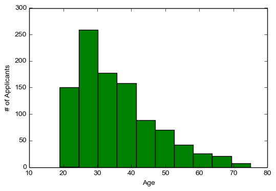

```python
%matplotlib inline
import numpy as np
import matplotlib.mlab as mlab
import matplotlib.pyplot as plt


# the histogram of the data
plt.hist(df["Age (years)"], facecolor='green')
plt.xlabel('Age')
plt.ylabel('# of Applicants')
plt.show()
```

Plot the datapoints

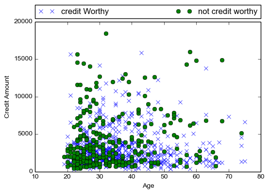

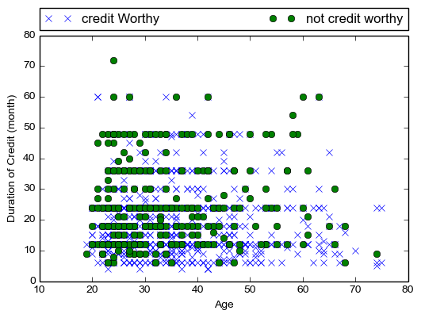

```python
creditWorthy = df[df['Creditability']==1]
notCreditWorthy = df[df['Creditability']==0]

plt.plot(creditWorthy["Age (years)"],creditWorthy["Credit Amount"],'x', label = 'credit Worthy')
plt.plot(notCreditWorthy["Age (years)"],notCreditWorthy["Credit Amount"],'o', label = 'not credit worthy')

plt.xlabel('Age')
plt.ylabel('Credit Amount')
plt.legend(bbox_to_anchor=(0., 1.02, 1., .102), loc=3,
           ncol=2, mode="expand", borderaxespad=0.)

plt.show()


plt.plot(creditWorthy["Age (years)"],creditWorthy["Duration of Credit (month)"],'x', label = 'credit Worthy')
plt.plot(notCreditWorthy["Age (years)"],notCreditWorthy["Duration of Credit (month)"],'o', label = 'not credit worthy')

plt.xlabel('Age')
plt.ylabel('Duration of Credit (month)')
plt.legend(bbox_to_anchor=(0., 1.02, 1., .102), loc=3,
           ncol=2, mode="expand", borderaxespad=0.)

ts = pd.Series(np.random.randn(1000), index=pd.date_range('1/1/2000', periods=1000))
plt.show()
```

Plotting dataframe series

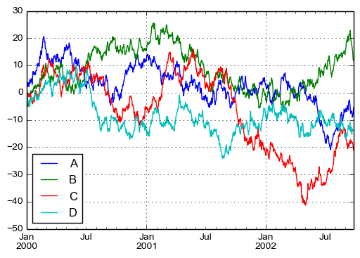

```python
ts = pd.Series(np.random.randn(1000), index=pd.date_range('1/1/2000', periods=1000))

df = pd.DataFrame(np.random.randn(1000, 4), index=ts.index,\
                  columns=['A', 'B', 'C', 'D'])

df = df.cumsum()

plt.figure(); df.plot(); plt.legend(loc='best')

plt.show()
```

# Scikit Learn

## Load the Dataset

```python
from sklearn.datasets import fetch_20newsgroups

twenty_train = fetch_20newsgroups(subset='train', shuffle=True, random_state=42)

print str(len(twenty_train.data)) + " training data points were loaded!"
```

```
11314 training data points were loaded!
```

The 20 different categories of the dataset and the number of documents for each category.

```python
from collections import Counter

cnt = Counter()
for category in twenty_train.target:
    cnt[category] += 1

for category in list(set(twenty_train.target)):
    print twenty_train.target_names[category] + "  " + str(cnt[category]) + " Documents"
```

```
alt.atheism  480 Documents
comp.graphics  584 Documents
comp.os.ms-windows.misc  591 Documents
comp.sys.ibm.pc.hardware  590 Documents
comp.sys.mac.hardware  578 Documents
comp.windows.x  593 Documents
misc.forsale  585 Documents
rec.autos  594 Documents
rec.motorcycles  598 Documents
rec.sport.baseball  597 Documents
rec.sport.hockey  600 Documents
sci.crypt  595 Documents
sci.electronics  591 Documents
sci.med  594 Documents
sci.space  593 Documents
soc.religion.christian  599 Documents
talk.politics.guns  546 Documents
talk.politics.mideast  564 Documents
talk.politics.misc  465 Documents
talk.religion.misc  377 Documents
```

Print the content of the first 5 documents

```python
for i in range(5):
    print "\n\n<------------- Document " + str(i) + " ------------->"
    print "<------------- " + twenty_train.target_names[twenty_train.target[i]] + " ------------->"
    print twenty_train.data[i]
```

```
<------------- Document 0 ------------->
<------------- rec.autos ------------->
From: lerxst@wam.umd.edu (where's my thing)
Subject: WHAT car is this!?
Nntp-Posting-Host: rac3.wam.umd.edu
Organization: University of Maryland, College Park
Lines: 15

 I was wondering if anyone out there could enlighten me on this car I saw
the other day. It was a 2-door sports car, looked to be from the late 60s/
early 70s. It was called a Bricklin. The doors were really small. In addition,
the front bumper was separate from the rest of the body. This is
all I know. If anyone can tellme a model name, engine specs, years
of production, where this car is made, history, or whatever info you
have on this funky looking car, please e-mail.

Thanks,
- IL
   ---- brought to you by your neighborhood Lerxst ----







<------------- Document 1 ------------->
<------------- comp.sys.mac.hardware ------------->
From: guykuo@carson.u.washington.edu (Guy Kuo)
Subject: SI Clock Poll - Final Call
Summary: Final call for SI clock reports
Keywords: SI,acceleration,clock,upgrade
Article-I.D.: shelley.1qvfo9INNc3s
Organization: University of Washington
Lines: 11
NNTP-Posting-Host: carson.u.washington.edu

A fair number of brave souls who upgraded their SI clock oscillator have
shared their experiences for this poll. Please send a brief message detailing
your experiences with the procedure. Top speed attained, CPU rated speed,
```

[output cut: 99 more lines]

```
> Parity errors in memory or previously known conditions that were waivered.
>    "Yes that is an error, but we already knew about it"
> I'd be curious as to what the real meaning of the quote is.
>
> tom


My understanding is that the 'expected errors' are basically
known bugs in the warning system software - things are checked
that don't have the right values in yet because they aren't
set till after launch, and suchlike. Rather than fix the code
and possibly introduce new bugs, they just tell the crew
'ok, if you see a warning no. 213 before liftoff, ignore it'.

 - Jonathan
```

# Preprocessing

Use a Vectorizer to convert a collection of text documents to a matrix of token counts, in order to perform machine learning on text documents.

```python
from sklearn.feature_extraction.text import CountVectorizer
from sklearn.feature_extraction.text import ENGLISH_STOP_WORDS

my_additional_stop_words=['Antonia','Nikos','Nikolas']
stop_words = ENGLISH_STOP_WORDS.union(my_additional_stop_words)
count_vect = CountVectorizer(stop_words=stop_words)
count_vect.fit(twenty_train.data)
X_train_counts = count_vect.transform(twenty_train.data)
X_train_counts.shape
```

```
(11314, 129796)
```

```python
from sklearn.naive_bayes import MultinomialNB
clf = MultinomialNB().fit(X_train_counts, twenty_train.target)

docs_new = ['God is love', 'OpenGL on the GPU is fast']
X_new_counts = count_vect.transform(docs_new)

print X_new_counts

predicted = clf.predict(X_new_counts)

for doc, category in zip(docs_new, predicted):
    print('%r => %s' % (doc, twenty_train.target_names[category]))
```

```
  (0, 59517)	1
  (0, 76732)	1
  (1, 54379)	1
  (1, 59852)	1
  (1, 89859)	1
'God is love' => soc.religion.christian
'OpenGL on the GPU is fast' => comp.graphics
```

Evaluate the algorithm in a new document

```python
document = """
Arsenal manager Arsene Wenger said Gunners fans were "absolutely sensational" during their 2-2 draw with Manchester City, despite further fan protests at Emirates Stadium.

Wenger, who is under pressure following one win in six matches and a slide down the Premier League table, has faced calls to resign from some fans.

"I must say, despite all that has happened on the fans front, our fans were fantastic today," said the Frenchman, whose side twice hit back to earn a draw against City.

"In very difficult moments our fans, at 1-0 down and 2-1 down, could have turned against us but I think they were absolutely sensational to get us through those difficult moments."

Goals from Theo Walcott and Shkodran Mustafi cancelled out efforts from Leroy Sane and Sergio Aguero in a performance Wenger believed "built confidence to help us to come back to our natural fluency."

    Football Daily podcast: 'Arsenal players showed they're behind Wenger'
    'If Wenger goes now, Arsenal will fall apart' - Ian Wright
    How Arsenal came from behind to claim point
    'Arsenal showed signs of recovery' - Phil McNulty

Wenger, who is out of contract at the end of the season, has been offered a two-year extension and said on 18 March he will announce his future plans "very soon".

Former Arsenal goalkeeper Bob Wilson told BBC Radio 5 Live's Sportsweek programme that Wenger "should declare his future for the good of the club."

But when pressed on his future following Sunday's draw, he said: "I've shown great loyalty and always committed. I don't know how long I am here but I love the club and will do my best. I am clear in my mind, it will be soon, don't worry."

Arsenal are sixth in the Premier League table, seven points behind fourth-placed Manchester City.

The Gunners face West Ham at home on Wednesday and then travel to Crystal Palace the following Monday.
Banner in support of Arsene Wenger
There were messages in support and in protest of Arsene Wenger at the Emirates Stadium
This banner highlighted a quote that chief executive Ivan Gazidis made regarding the manager &amp;quot;being accountable to the fans&amp;quot;
This banner highlighted a quote that chief executive Ivan Gazidis made regarding the manager "being accountable to the fans" """

X_new_counts = count_vect.transform([document])

predicted = clf.predict(X_new_counts)

print "Predicted category => " + str(twenty_train.target_names[predicted[0]])
```

```
Predicted category => rec.sport.hockey
```

### Pipeline

```python
from sklearn.pipeline import Pipeline
from sklearn.feature_extraction.text import TfidfTransformer
from sklearn.naive_bayes import MultinomialNB

text_clf = Pipeline([('vect', CountVectorizer(stop_words='english')),\
                    ('tfidf', TfidfTransformer()),\
                    ('clf', MultinomialNB()),
                    ])

text_clf = text_clf.fit(twenty_train.data, twenty_train.target)
```

### Evaluation

Evaluate the performance on the test set

```python
twenty_test = fetch_20newsgroups(subset='test', shuffle=True, random_state=42)
docs_test = twenty_test.data
predicted = text_clf.predict(docs_test)
np.mean(predicted == twenty_test.target)
```

```
0.81691449814126393
```

### Classification Report

```python
from sklearn.metrics import classification_report

print(classification_report(predicted, twenty_test.target, target_names=twenty_train.target_names))
```

```
                          precision    recall  f1-score   support

             alt.atheism       0.69      0.80      0.74       274
           comp.graphics       0.72      0.78      0.75       357
 comp.os.ms-windows.misc       0.72      0.79      0.75       358
comp.sys.ibm.pc.hardware       0.81      0.68      0.74       463
   comp.sys.mac.hardware       0.81      0.86      0.84       361
          comp.windows.x       0.78      0.87      0.82       357
            misc.forsale       0.80      0.87      0.83       359
               rec.autos       0.91      0.88      0.90       410
         rec.motorcycles       0.96      0.93      0.95       408
      rec.sport.baseball       0.92      0.91      0.92       403
        rec.sport.hockey       0.98      0.88      0.93       445
               sci.crypt       0.96      0.75      0.84       506
         sci.electronics       0.65      0.84      0.74       303
                 sci.med       0.79      0.92      0.85       338
               sci.space       0.94      0.82      0.88       451
  soc.religion.christian       0.96      0.62      0.76       613
      talk.politics.guns       0.95      0.66      0.78       520
   talk.politics.mideast       0.94      0.95      0.94       374
      talk.politics.misc       0.52      0.94      0.67       170
      talk.religion.misc       0.24      0.95      0.38        62

             avg / total       0.85      0.82      0.82      7532
```

### Cross Validation

```python
from sklearn.model_selection import KFold

kf = KFold(n_splits=5)
# kf.get_n_splits(twenty_train.data)
fold = 0
for train_index, test_index in kf.split(twenty_train.data):
    X_train_counts = count_vect.transform(np.array(twenty_train.data)[train_index])
    X_test_counts = count_vect.transform(np.array(twenty_train.data)[test_index])

    clf_cv = MultinomialNB().fit(X_train_counts, np.array(twenty_train.target)[train_index])
    yPred = clf_cv.predict(X_test_counts)
    fold += 1
    print "Fold " + str(fold)
    print(classification_report(yPred, np.array(twenty_train.target)[test_index], target_names=twenty_train.target_names))
```

```
Fold 1
                          precision    recall  f1-score   support

             alt.atheism       0.94      0.89      0.91       108
           comp.graphics       0.93      0.62      0.75       152
 comp.os.ms-windows.misc       0.22      1.00      0.36        28
comp.sys.ibm.pc.hardware       0.84      0.62      0.71       142
   comp.sys.mac.hardware       0.85      0.88      0.87       121
          comp.windows.x       0.94      0.73      0.82       148
            misc.forsale       0.76      0.91      0.83       103
               rec.autos       0.89      0.92      0.91       119
         rec.motorcycles       0.93      0.96      0.95       120
      rec.sport.baseball       0.94      0.94      0.94       124
        rec.sport.hockey       0.95      0.94      0.94       117
               sci.crypt       0.95      0.94      0.94       117
         sci.electronics       0.84      0.87      0.86       116
                 sci.med       0.96      0.95      0.95       117
               sci.space       0.99      0.89      0.94       111
  soc.religion.christian       0.93      0.91      0.92       139
      talk.politics.guns       0.97      0.91      0.94       126
   talk.politics.mideast       0.97      0.95      0.96       120
      talk.politics.misc       0.92      0.83      0.87        93
      talk.religion.misc       0.59      0.98      0.74        42

             avg / total       0.90      0.87      0.88      2263

Fold 2
                          precision    recall  f1-score   support

             alt.atheism       0.91      0.83      0.87       104
           comp.graphics       0.76      0.84      0.80       118
 comp.os.ms-windows.misc       0.31      0.97      0.47        34
comp.sys.ibm.pc.hardware       0.87      0.71      0.78       155
   comp.sys.mac.hardware       0.88      0.80      0.84       114
          comp.windows.x       0.94      0.69      0.80       172
            misc.forsale       0.78      0.90      0.84        94
               rec.autos       0.88      0.92      0.90       111
         rec.motorcycles       0.95      0.95      0.95       132
      rec.sport.baseball       0.98      0.97      0.98       117
        rec.sport.hockey       0.97      0.95      0.96       120
```

[output cut: 74 more lines]

```
               rec.autos       0.93      0.90      0.92       121
         rec.motorcycles       0.93      0.95      0.94       105
      rec.sport.baseball       0.93      0.97      0.95       111
        rec.sport.hockey       0.98      0.96      0.97       126
               sci.crypt       0.98      0.86      0.91       137
         sci.electronics       0.82      0.89      0.85       109
                 sci.med       0.96      0.93      0.95       120
               sci.space       0.98      0.92      0.95       149
  soc.religion.christian       0.96      0.82      0.88       140
      talk.politics.guns       0.96      0.86      0.91       125
   talk.politics.mideast       0.99      0.91      0.95       117
      talk.politics.misc       0.87      0.92      0.90       105
      talk.religion.misc       0.58      1.00      0.74        49

             avg / total       0.90      0.87      0.88      2262
```

### SVD

```python
from sklearn.decomposition import TruncatedSVD
from sklearn.linear_model import SGDClassifier
from sklearn.naive_bayes import GaussianNB
from sklearn.feature_extraction.text import TfidfVectorizer

vectorizer = TfidfVectorizer()
vectorizer.fit_transform(twenty_train.data)
X_train_tfidf = vectorizer.transform(twenty_train.data)

svd = TruncatedSVD(n_components=500)
X_lsi = svd.fit_transform(X_train_tfidf)


clfSVD=SGDClassifier(loss='hinge', penalty='l2', alpha=1e-3, n_iter=5, random_state=42)\
        .fit(X_lsi,twenty_train.target)
# clfSVD = GaussianNB().fit(X_lsi, twenty_train.target)

X_test_lsi = svd.transform(vectorizer.transform(twenty_test.data))
predictedSVD = clfSVD.predict(X_test_lsi)

print np.mean(predictedSVD == twenty_test.target)
```

```
0.776420605417
```

```python
from sklearn.decomposition import TruncatedSVD
from sklearn.linear_model import SGDClassifier
from sklearn.naive_bayes import GaussianNB
from sklearn.feature_extraction.text import TfidfVectorizer

vectorizer = TfidfVectorizer()
vectorizer.fit_transform(twenty_train.data)
X_train_tfidf = vectorizer.transform(twenty_train.data)

svd = TruncatedSVD(n_components=200)
X_lsi = svd.fit_transform(X_train_tfidf)


clfSVD=SGDClassifier(loss='hinge', penalty='l2', alpha=1e-3, n_iter=5, random_state=42)\
        .fit(X_lsi,twenty_train.target)
# clfSVD = GaussianNB().fit(X_lsi, twenty_train.target)

X_test_lsi = svd.transform(vectorizer.transform(twenty_test.data))
predictedSVD = clfSVD.predict(X_test_lsi)

print np.mean(predictedSVD == twenty_test.target)
```

```
0.741635687732
```

```python
from sklearn.decomposition import TruncatedSVD
from sklearn.linear_model import SGDClassifier
from sklearn.naive_bayes import GaussianNB
from sklearn.feature_extraction.text import TfidfVectorizer

vectorizer = TfidfVectorizer()
vectorizer.fit_transform(twenty_train.data)
X_train_tfidf = vectorizer.transform(twenty_train.data)

svd = TruncatedSVD(n_components=100)
X_lsi = svd.fit_transform(X_train_tfidf)


clfSVD=SGDClassifier(loss='hinge', penalty='l2', alpha=1e-3, n_iter=5, random_state=42)\
        .fit(X_lsi,twenty_train.target)
# clfSVD = GaussianNB().fit(X_lsi, twenty_train.target)

X_test_lsi = svd.transform(vectorizer.transform(twenty_test.data))
predictedSVD = clfSVD.predict(X_test_lsi)

print np.mean(predictedSVD == twenty_test.target)
```

```
0.706718003186
```